# Kapittel 3

## Kapittel 3: Økonomisk teori 1: Offentlige inngrep

- Hovedmålet med dette kapittel 3 og kapittel 4 er å utvikle et rammeverk som
  - forklarer hvorfor det offentlige har betydelige inngrep i finansiering og/eller tilbud av enkelte tjenester som f.eks. helsevesen og utdanning, men overlater andre til det private markedet
- Hovedspørsmålene gjelder **økonomisk effektivitet** og **sosial rettferdighet**

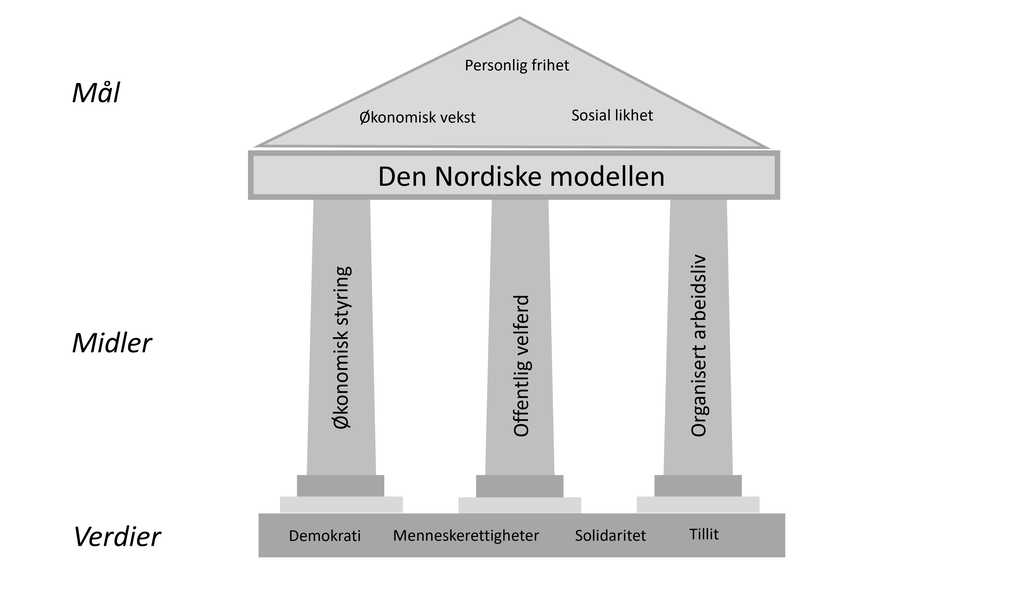

## Målet: å maksimere samfunnets velferd

- Målet: **maksimere velferden**
  - en grunnleggende antakelse i økonomisk teori: Vi søker etter allokeringer som gir så høy velferd som mulig til samfunnet, gitt de realøkonomiske rammene
    - preferanser
    - teknologi
    - tilgjengelige ressurser

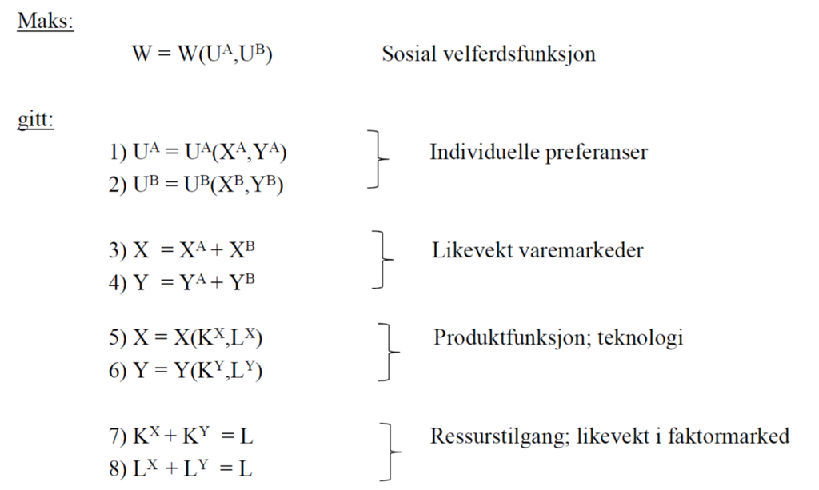

## 3.2 Hvorfor er økonomisk effektivitet ett av målene med politikken?

## 3.2.1 Effektivitetsbegrepet

```
# A tibble: 1 × 2
      x     y
  <dbl> <dbl>
1  4.65  3.40
```

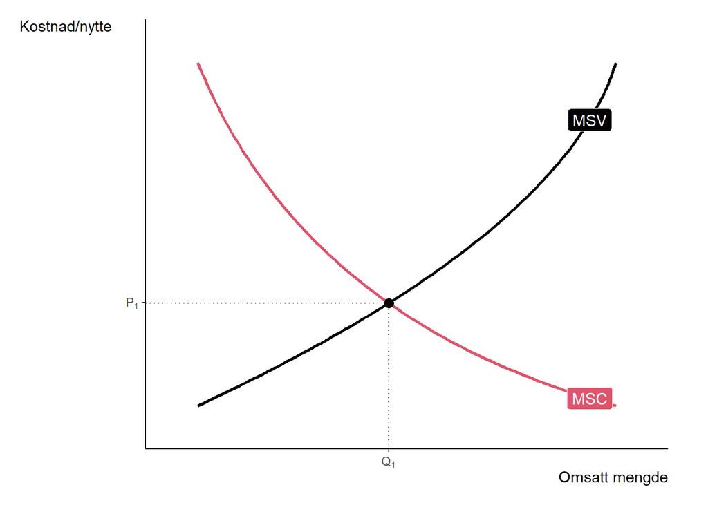

```r
library(econocharts)
#Drawing market equilibrium
sdcurve(names = c("MSV", "MSC"),
        xlab = "Omsatt mengde",              # X-axis label
        ylab = "Kostnad/nytte")             # Y-axis label
```

## Paretooptimalitet = samfunnsøkonomisk effektivitet

- innebærer at følgende tre kriterier er oppfylt:
  1. **Bytteeffektivitet** (en persons forbruksvalg burde maksimere hans eller hennes nytte):
     - konsumentsiden
       - Hvordan bør varer og tjenester fordeles mellom ulike brukere?
  2. **Produksjonseffektivitet** (produseres mest mulig med minst mulig bruk av ressurser)
     - produsentsiden
       - Hvordan bør varer produseres?
  3. **Sammensetningseffektivitet** (man produserer det som konsumentene ettertrakter)
     - Hvilke varer som bør produseres og i hvilket omfang?
- dersom disse kriteriene **ikke er oppfylt** er det mulig å gjøre endringer slik at minst én får det bedre uten at noen får det verre (= en paretoforbedring)
- Når vi har gjort alle slike endringer (**paretoforbedringer**) er allokeringen **paretooptimal** - **ingen kan få det bedre uten at minst én får det verre**

## Bytteeffektivitet

- oppfylt når godene i økonomien er fordelt på en slik måte at ingen kan få det bedre, uten at noen andre får det verre
  - alle muligheter for gjensidig fordelaktige bytter av varer og tjenester er utnyttet
  - **varer og tjenester går til dem som verdsetter dem høyest**
- oppfylt når marginal betalingsvillighet for en vare - målt i hva man er villig til å gi opp av en annen vare - er den samme for alle konsumentene
- I et marked med fullkommen konkurranse vil konsumentene tilpasse seg slik at deres marginale substitusjonsbrøk (= helningen til indifferenskurvene) er lik: $MRS_{Adam} = MRS_{Eva}$
  - konsumentenes verdsetting av godene er nøyaktig lik
    - hvis marginale substitusjonsbrøk mellom konsumenter er **ulike** er det gevinster forbundet med direkte bytte mellom forbrukere
- for analyse, [se video (knyttet til Figur 3.3 i Barr)](https://uit.cloud.panopto.eu/Panopto/Pages/Viewer.aspx?id=a93ae20e-e503-4efc-9ee3-aef600e3f9be)
- i fullkommen konkurranse står alle konsumentene ovenfor samme pris
  - alle konsumentene vil sette det marginale substitusjonsbrøk lik prisforholdet

## Produksjonseffektivitet

- innebærer at en ikke skal bruke større mengder innsatsfaktorer (eks: arbeid, kapital) enn det som trengs for å produsere en gitt mengde varer og tjenester
- dersom det er mulig å øke produksjonen av en vare uten å redusere produksjonen av andre varer, har man ikke effektivitet i produksjonen
- den marginale transformasjonsraten (MRT) viser hvor mye man må redusere produksjonen av et gode for å kunne produsere én enhet til av et annet gode
  - bedriften produserer inntil punktet der marginalkostnaden er lik prisen; $MC = P$(profittmaksimering)

```r
suppressPackageStartupMessages(library(tidyverse))
suppressPackageStartupMessages(library(dplyr))
library(econocharts)
library(ggplot2)
p <- ppf(x = 4:6,                   # Intersections
         main = "Produksjonsmulighetskurve",              # Title
         geom = "text",             # Intersection labels as text
         generic = TRUE,            # Generic axis tick labels
         labels = c("A", "B", "C"), # Custom labels
         xlab = "Produkt B",        # X-axis label
         ylab = "Produkt A",        # Y-axis label
         acol = 3)                  # Color of the area
```

```
# A tibble: 3 × 2
      x     y
  <dbl> <dbl>
1  4.25  4.00
2  3.10  5.00
3  1.36  6.00
```

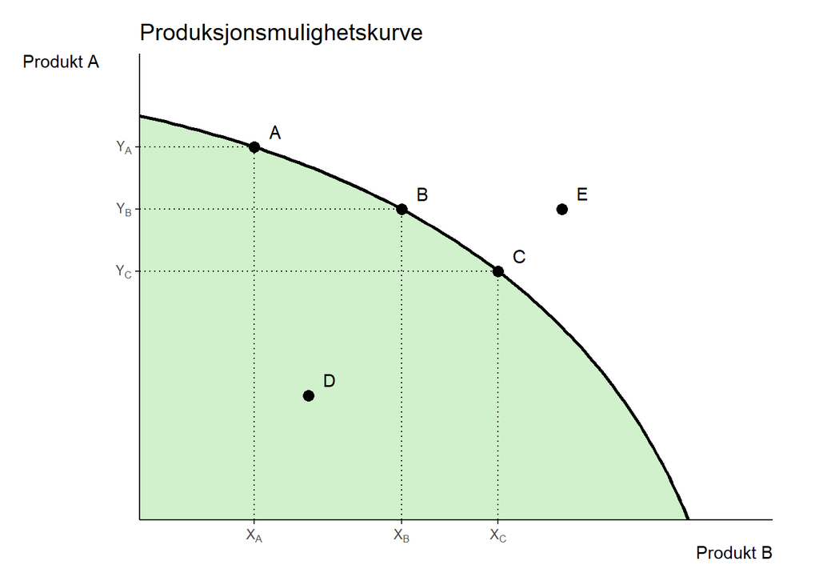

```r
# Add more layers to the plot
p$p + geom_point(data = data.frame(x = 5, y = 5), size = 3) +
  geom_point(data = data.frame(x = 2, y = 2), size = 3) +
  annotate(geom = "text", x = 2.25, y = 2.25, label = "D") +
  annotate(geom = "text", x = 5.25, y = 5.25, label = "E")
```

## Sammensetningseffektivitet

- knytter sammen konsument- og produsentsiden
- handler om å produsere “optimal” mengde av varer og tjenester, altså det konsumentene ønsker
- Sammensetningseffektivitet innebærer at marginal substitusjonsbrøk for en vare må være lik marginal transformasjonsrate ved å produsere varen
  - **Profittmaksimerenede bedrifter sammen med konsumentenes nyttemaksimerende adferd leder til paretooptimalitet**

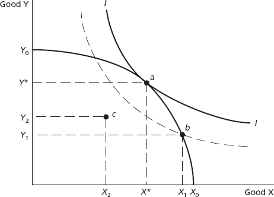

## 3.3 Offentlige inngrep av effektivitetsgrunner

## 3.3.1 Velferdsteoriens to grunnleggende hovedteoremer

- En først-best økonomi er kjennetegnet av:
  - fullkommen konkurranse
  - full informasjon
  - rasjonell adferd
  - perfekte markeder
  - ikke-vridende skatter
- ikke en beskrivelse av virkeligheten, men som en målestokk for å evaluere politikken

## Velferdsteoriens grunnleggende hovedteoremer

- **Det første grunnleggende hovedteoremet** (også kalt ‘usynlig hånd’ -teoremet) viser at i en først-best økonomi vil frikonkurranse føre til en paretoeffektiv allokering av ressurser
- **Det andre grunnleggende hovedteoremet** viser at man i en først-best økonomi kan oppnå enhver Paretooptimal tilstand vi måtte ønske med en passende omfordeling av ressurser
  - f.eks. ved lump-sum beskatning: ikke-vridende fordi individer ikke kan unngå den ved å endre atferden

Det andre velferdsteoremet: Tenk deg at du deler kaken mellom venner. Du kan velge å dele kaken likt, gi mer til de som er sultnere, eller hva enn du føler er rettferdig. Når alle er enige om hvordan kaken er delt (omfordeling av ressurser), kan hver venn bytte kakestykker med hverandre (markedshandel) til ingen kan få det bedre uten at oen får det verre (Pareto-effektivitet).

Sammenfattet gir det andre fundamentale velferdsteoremet en mekanisme som tillater samfunnet å nå en ønsket sosial tilstand gjennom markedskrefter, forutsatt at ressursene er riktig fordelt fra starten. Det gir et sterkt argument for at myndighetene kan ha en rolle i å forme startfordelingen av ressurser, og deretter la markedet ta seg av resten.

## Ulike typer av offentlige inngrep

- regulering
- avgift/subsidie
- offentlig produksjon
- inntektsoverføringer

## Markedssvikt (= brudd i først-best-antakelsene)

- ufullkommen konkurranse (monopol, oligopol osv.)
- eksternaliteter
- kollektive goder
- stordriftsfordeler
- mangelfull informasjon (the economics of information)
- ikke-rasjonell atferd (atferdsøkonomi - behavioural economics)
- ufullstendige markeder, ufullstendige kontrakter
- Vridende skatter

## 3.3.2 Markedssviktene

- **ufullkommen konkurranse** (monopol, oligopol, monopson osv.)
  - en situasjon der individuelle selgere/kjøpere har muligheten til å påvirke markedsprisen på sine produkter eller tjenester betydelig (prisen høyere enn marginalkostnaden)
- **eksternaliteter**
  - kostnader eller gevinster som konsumenter eller produsenter påfører andre uten at de tar hensyn til at deres beslutninger påvirker andre
    - et eksempel er den samfunnsøkonomiske kostnaden knyttet til forurensning fra en produsent av kjemikalier
      - uten et inngrep fra det offentlige vil en slik produsent ikke ha insentiver til å ta hensyn til de samfunnsøkonomiske kostnadene av forurensning -> vil produsere for mye
- **kollektive goder**
  - goder karakterisert ved ikke-rivaliserende og ikke-ekskluderbar
  - ikke-rivaliserende: grensekostnaden ved at én person til får tilgang på godet er lik 0
  - ikke-ekskluderbar: ingen kan stenges ute fra å benytte seg av godet
    - gratispassasjer: en konsument eller produsent som ikke betaler for et ikke-ekskluderbart gode i forventning om at andre ville betale for det
- **stordriftsfordeler**
  - det å produsere mange varer eller tjenester er billigere per produserte enhet enn om man produserer i mindre skala
  - betegner en kostnadsstruktur som er slik at de langsiktige gjennomsnittskostnadene faller med økende produksjon
- **ufullkommen informasjon**
  - mangelfull informasjon om
    - kvalitet
    - pris
    - fremtiden
  - jo bedre informasjon, desto bedre valg gjør forbrukere
- **ikke-rasjonell adferd**
  - begrenset rasjonalitet: forbundet med mangelfull informasjon.
    - f.eks. valg av farmasøytiske legemidler
  - begrenset viljestyrke
    - Valg om kosthold og livsstil
    - Valg om sparing
- **imperfekte markeder og ufullstendige kontrakter**
  - Imperfekte markeder kan føre til ikke-eksisterende produkter
    - ingen kjenner fremtidig inflasjon, så det er generelt ikke mulig å kjøpe inflasjonsforsikring
  - ufullstendige kontrakter, ofte på grunn av asymmetrisk informasjon, fører til problemer med å kontrollerere kvalitet
- **vridende skatter**
  - Lump-sum-skatter er ikke-vridende, siden enkeltpersoner ikke kan unngå å betale dem ved å endre atferden
  - men fattigdomsbekjempelse krever at vi må skatte inntekt eller forbruk
    - En inntektsskatt vil endre arbeidstilbudet
    - En skatt på renteinntekter kan endre spareatferd

Støttevideo for Box 3.6 i pensumboka finner du [her](https://uit.cloud.panopto.eu/Panopto/Pages/Viewer.aspx?id=a93ae20e-e503-4efc-9ee3-aef600e3f9be)

## 3.3.7 Hvorfor trenger vi en velferdsstat?

- Teoretisk konklusjon: vi trenger ikke en velferdsstat i en verden:
  - der de først-beste forutsetningene holder; og
  - der vi ikke bryr oss om fordelingen av ressurser eller der fordelingen kan håndteres ved å bruke lump-sum-skatter

## Politiske implikasjoner

- Der én eller flere av de først-beste forutsetningene svikter, er det nødvendig å stille tre spørsmål:
  - Kan markedet løse problemet selv?
  - Hvis ikke, hvilken type intervensjon – regulering, avgift/subsidie eller offentlig produksjon – eller blanding av disse kan forbedre effektiviteten?
  - Vil intervensjon være kostnadseffektiv?

## 3.4 Inngrep av hensyn til sosial rettferdighet

## 3.4.1 Hvorfor skjer omfordeling?

- tvungen omfordeling («tvang via stemmeseddelen», “de fattige” bruker sin stemmeinnflytelse for å tvinge gjennom omfordeling fra “de rike”)
- frivillig omfordeling: Veldedighet og gratispassasjerproblemet

## 3.4.2 Omfordeling i form av kontanter eller naturalia?

- økonomiske argumenter: markedssvikt
- Politisk økonomi -argumenter: formyndergoder
  - enkelte konsumenter (fra myndighetenes synspunkt) “vet ikke sitt eget beste”

## 3.4.3 Horisontal likhet

- Lik tilgang
- Like muligheter

## 3.6 Privatiseringsspørsmålet

- Privatisering er et mer komplisert konsept enn man tror:
  - Hvem produserer varen?
  - Hvem finansierer det?
  - Hvem bestemmer total produksjon?
  - Hvem bestemmer hvor mye hver person vil konsumere?

## To viktige resultater fra økonomisk teori

- Hvis først-best-forutsetningene holder, vil markedsallokeringen være effektiv
  - I dette tilfellet bør rettferdighet generelt oppnås gjennom inntektsoverføringer
    - f.eks. slik at fattige mennesker kan kjøpe mat til markedspriser
- Hvis først-best-forutsetningene ikke holder, kan dette rettferdiggjøre offentlig produksjon og omfordeling:
  - rettferdighet kan da på en hensiktsmessig måte oppnås gjennom naturalia-overføringer (f.eks. gratis skoleutdanning).